# Part II - PISA 2012 Analysis

## - Shalom Karunwi

## Investigation Overview

> - There was a high-level of performance among the students with differences in grades being minimal
> - The assessment was not gender-biased and nothing could split male and female students in terms of academic performance
> - Parental influence was strong, as those with degrees groomed students who performed better academically. Although, non-natives whose parents had no degrees were also high-achievers.
> - Number of students in a class did not affect academic performance
> - Longer hours of learning did not equate better academic performance

## Dataset Overview

> The dataset consists of 212,297 rows and 23 columns. A truncated form of the main PISA dataset which is a survey of students' skills and knowledge as they approach the end of compulsory education. It examines how well the students have learned the school curriculum and how well prepared they are for life beyond school.

## Correlation Between Students' Grades

> The students were high-achievers, good grades were consistent in all three subjects despite different technical requirements

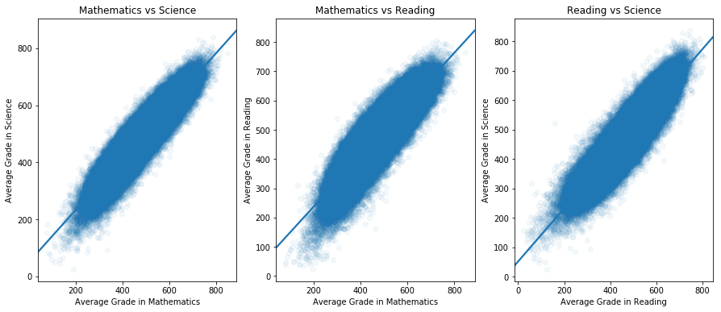

## Gender-based Assessment

> Both genders were highly competitive and maintained almost identical academic performances

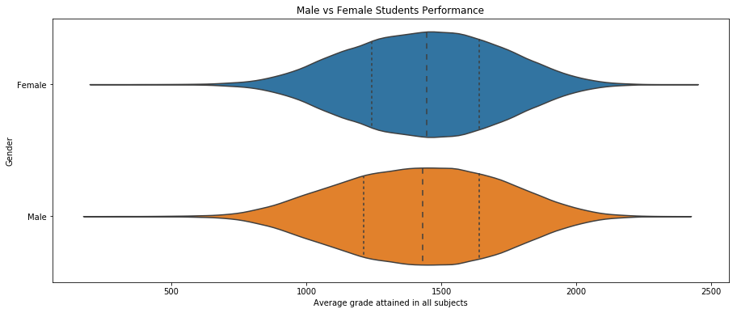

## Parental Influence (Education)

> Parental affinity for education rubbed off on their children

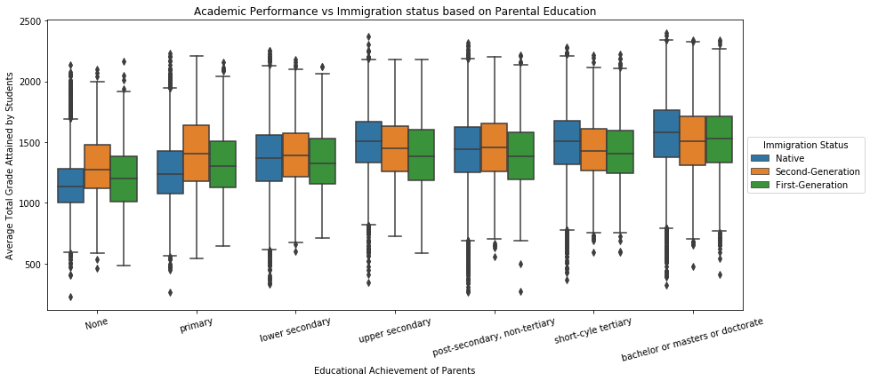

## Does Size Matter?

> Having a large or small class did not result in better performances. 25 students in a class was the consistent number.

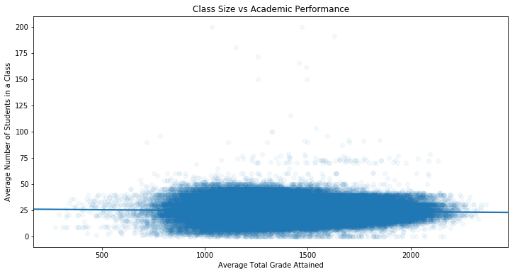

> Spending more time in the classroom did not directly result in a greater academic performance

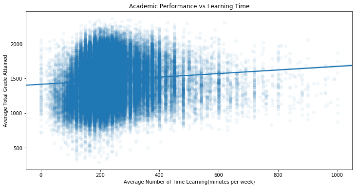